# Working with sf objects

Sofie Thinggaard

22-02-08 updated 2022-02-11

## Installing packages

```r
#install.packages("raster")
library(raster)
#install.packages("sf")
library(sf)
#install.packages("tmap")
library(tmap)
#install.packages("spData")
library(spData)
# To install the spDataLarge uncomment the next line
#install.packages("spDataLarge", repos = "https://geocompr.r-universe.dev")
library(spDataLarge)
```

# Exercise 1 - Make a map

## Non-improved map

```
## stars object downsampled to 877 by 1140 cells. See tm_shape manual (argument raster.downsample)
```

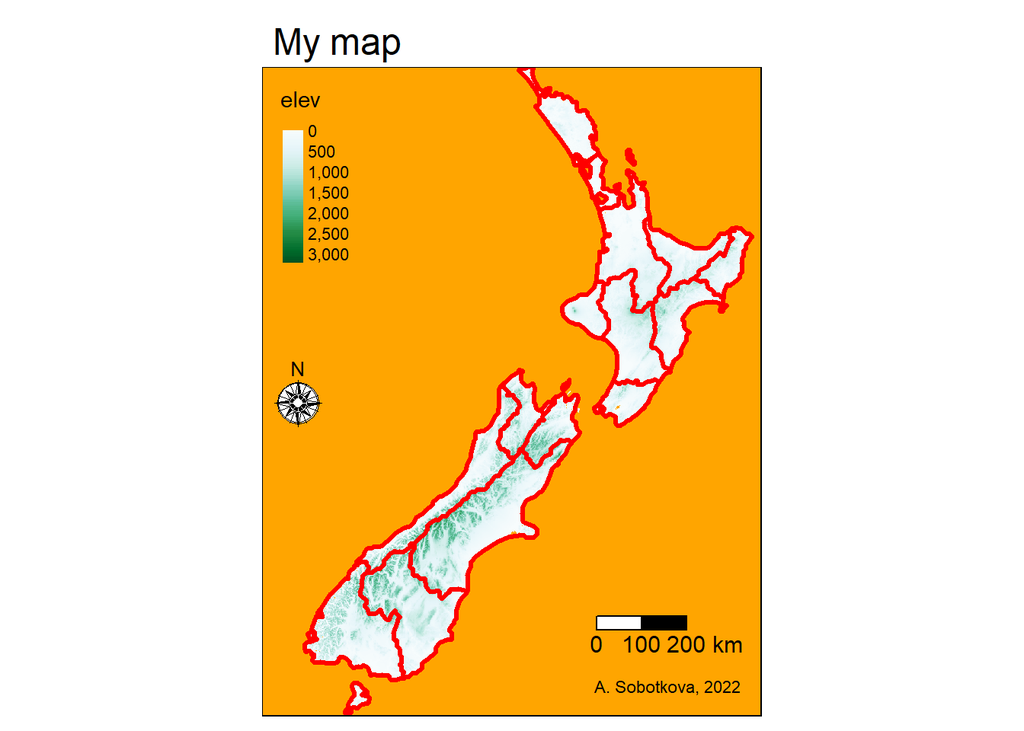

```r
tm_shape(nz_elev)  +
  tm_raster(title = "elev",
            style = "cont",
            palette = "BuGn") +
  tm_shape(nz) +
  tm_borders(col = "red",
             lwd = 3) +
  tm_scale_bar(breaks = c(0, 100, 200),
               text.size = 1) +
  tm_compass(position = c("LEFT", "center"),
             type = "rose",
             size = 2) +
  tm_credits(text = "A. Sobotkova, 2022") +
  tm_layout(main.title = "My map",
            bg.color = "orange",
            inner.margins = c(0, 0, 0, 0))
```

# Tasks

1. Change the map title from “My map” to “New Zealand”.
2. Update the map credits with your own name and today’s date.
3. Change the color palette to “-RdYlGn”. (You can also try other palettes from http://colorbrewer2.org/)
4. Put the north arrow in the top right corner of the map.
5. Improve the legend title by adding the used units (m asl).
6. Increase the number of breaks in the scale bar.
7. Change the borders’ color of the New Zealand’s regions to black. Decrease the line width.
8. Change the background color to any color of your choice.

## Your solution

```r
tm_shape(nz_elev)  +
  tm_raster(title = "m asl",
            style = "cont",
            palette = "-RdYlGn") +
  tm_shape(nz) +
  tm_borders(col = "black",
             lwd = 1) +
  tm_scale_bar(breaks = c(0, 50, 100, 150, 200),
               text.size = 1) +
  tm_compass(position = c("RIGHT", "top"),
             type = "rose",
             size = 2) +
  tm_credits(text = "S. Thinggaard, 08-February-2022") +
  tm_layout(main.title = "New Zealand",
            bg.color = "pink",
            inner.margins = c(0, 0, 0, 0))
```

```
## stars object downsampled to 877 by 1140 cells. See tm_shape manual (argument raster.downsample)
```

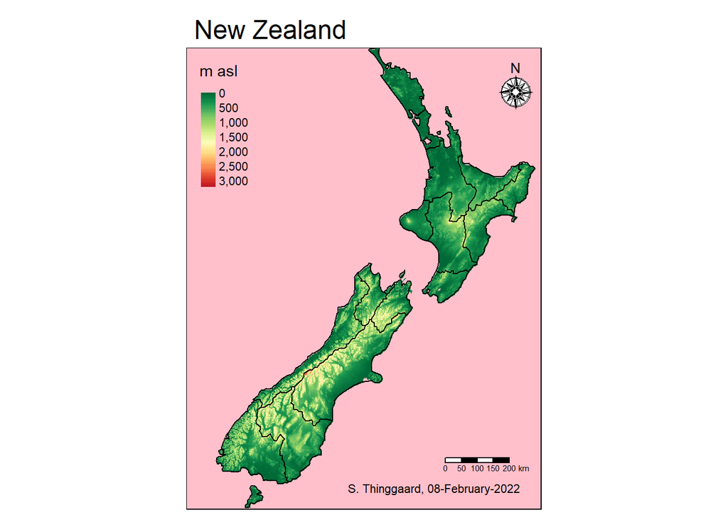

# Exercise 2 - Inspect and display spatial data

#### Preparation: Load data from provided package

```r
#install.packages("rgdal") #need additional package to work
library(rgdal)
srtm  <-  raster(system.file("raster/srtm.tif", package = "spDataLarge"))
zion  <-  read_sf(system.file("vector/zion.gpkg", package = "spDataLarge"))
```

## Instructions and questions

```r
zion
```

```
## Simple feature collection with 1 feature and 11 fields
## Geometry type: POLYGON
## Dimension:     XY
## Bounding box:  xmin: 302903.1 ymin: 4112244 xmax: 334735.5 ymax: 4153087
## Projected CRS: UTM Zone 12, Northern Hemisphere
## # A tibble: 1 x 12
##   UNIT_CODE GIS_Notes       UNIT_NAME  DATE_EDIT  STATE REGION GNIS_ID UNIT_TYPE
##   <chr>     <chr>           <chr>      <date>     <chr> <chr>  <chr>   <chr>
## 1 ZION      Lands - http:/~ Zion Nati~ 2017-06-22 UT    IM     1455157 National~
## # ... with 4 more variables: CREATED_BY <chr>, METADATA <chr>, PARKNAME <chr>,
## #   geom <POLYGON [m]>
```

```r
crs(zion)
```

```
## Coordinate Reference System:
## Deprecated Proj.4 representation:
##  +proj=utm +zone=12 +ellps=GRS80 +towgs84=0,0,0,0,0,0,0 +units=m
## +no_defs
## WKT2 2019 representation:
## BOUNDCRS[
##     SOURCECRS[
##         PROJCRS["UTM Zone 12, Northern Hemisphere",
##             BASEGEOGCRS["GRS 1980(IUGG, 1980)",
##                 DATUM["unknown",
##                     ELLIPSOID["GRS80",6378137,298.257222101,
##                         LENGTHUNIT["metre",1,
##                             ID["EPSG",9001]]]],
##                 PRIMEM["Greenwich",0,
##                     ANGLEUNIT["degree",0.0174532925199433]]],
##             CONVERSION["UTM zone 12N",
##                 METHOD["Transverse Mercator",
##                     ID["EPSG",9807]],
##                 PARAMETER["Latitude of natural origin",0,
##                     ANGLEUNIT["degree",0.0174532925199433],
##                     ID["EPSG",8801]],
##                 PARAMETER["Longitude of natural origin",-111,
##                     ANGLEUNIT["degree",0.0174532925199433],
##                     ID["EPSG",8802]],
##                 PARAMETER["Scale factor at natural origin",0.9996,
##                     SCALEUNIT["unity",1],
##                     ID["EPSG",8805]],
##                 PARAMETER["False easting",500000,
##                     LENGTHUNIT["Meter",1],
##                     ID["EPSG",8806]],
##                 PARAMETER["False northing",0,
##                     LENGTHUNIT["Meter",1],
##                     ID["EPSG",8807]],
##                 ID["EPSG",16012]],
##             CS[Cartesian,2],
##                 AXIS["(E)",east,
##                     ORDER[1],
##                     LENGTHUNIT["Meter",1]],
##                 AXIS["(N)",north,
##                     ORDER[2],
```

[output cut: 18 more lines]

```
##             ID["EPSG",9606]],
##         PARAMETER["X-axis translation",0,
##             ID["EPSG",8605]],
##         PARAMETER["Y-axis translation",0,
##             ID["EPSG",8606]],
##         PARAMETER["Z-axis translation",0,
##             ID["EPSG",8607]],
##         PARAMETER["X-axis rotation",0,
##             ID["EPSG",8608]],
##         PARAMETER["Y-axis rotation",0,
##             ID["EPSG",8609]],
##         PARAMETER["Z-axis rotation",0,
##             ID["EPSG",8610]],
##         PARAMETER["Scale difference",1,
##             ID["EPSG",8611]]]]
```

- How many attributes does it contain?

```r
attributes(zion)
```

```
## $names
##  [1] "UNIT_CODE"  "GIS_Notes"  "UNIT_NAME"  "DATE_EDIT"  "STATE"
##  [6] "REGION"     "GNIS_ID"    "UNIT_TYPE"  "CREATED_BY" "METADATA"
## [11] "PARKNAME"   "geom"
##
## $row.names
## [1] 1
##
## $class
## [1] "sf"         "tbl_df"     "tbl"        "data.frame"
##
## $sf_column
## [1] "geom"
##
## $agr
##  UNIT_CODE  GIS_Notes  UNIT_NAME  DATE_EDIT      STATE     REGION    GNIS_ID
##       <NA>       <NA>       <NA>       <NA>       <NA>       <NA>       <NA>
##  UNIT_TYPE CREATED_BY   METADATA   PARKNAME
##       <NA>       <NA>       <NA>       <NA>
## Levels: constant aggregate identity
```

- What is its geometry? Polygon
- Display the `srtm` object and view its structure.

```r
srtm
```

```
## class      : RasterLayer
## dimensions : 457, 465, 212505  (nrow, ncol, ncell)
## resolution : 0.0008333333, 0.0008333333  (x, y)
## extent     : -113.2396, -112.8521, 37.13208, 37.51292  (xmin, xmax, ymin, ymax)
## crs        : +proj=longlat +datum=WGS84 +no_defs
## source     : srtm.tif
## names      : srtm
## values     : 1024, 2892  (min, max)
```

```r
crs(srtm)
```

```
## Coordinate Reference System:
## Deprecated Proj.4 representation: +proj=longlat +datum=WGS84 +no_defs
## WKT2 2019 representation:
## GEOGCRS["WGS 84 (with axis order normalized for visualization)",
##     DATUM["World Geodetic System 1984",
##         ELLIPSOID["WGS 84",6378137,298.257223563,
##             LENGTHUNIT["metre",1]]],
##     PRIMEM["Greenwich",0,
##         ANGLEUNIT["degree",0.0174532925199433]],
##     CS[ellipsoidal,2],
##         AXIS["geodetic longitude (Lon)",east,
##             ORDER[1],
##             ANGLEUNIT["degree",0.0174532925199433,
##                 ID["EPSG",9122]]],
##         AXIS["geodetic latitude (Lat)",north,
##             ORDER[2],
##             ANGLEUNIT["degree",0.0174532925199433,
##                 ID["EPSG",9122]]]]
```

- How many attributes does it contain?

```r
attributes(srtm)
```

[output not shown]

[output cut: 107 more lines]

```
##         AXIS["geodetic latitude (Lat)",north,
##             ORDER[2],
##             ANGLEUNIT["degree",0.0174532925199433,
##                 ID["EPSG",9122]]]]
##
## $history
## list()
##
## $z
## list()
##
## $class
## [1] "RasterLayer"
## attr(,"package")
## [1] "raster"
```

- How many dimensions does it have? Nrows= 457 Ncols= 465 Ncell= 212505
- What is the data resolution? 0.0008333333, 0.0008333333 (x, y)

# Exercise 3 - Reconciling Coordinate systems

## Instructions

- Reproject the `srtm` dataset into the coordinate reference system used in the `zion` object.
  - Create a new object `srtm2`
  - Visualize the results using the `plot()` function.
- Reproject the `zion` dataset into the coordinate reference system used in the `srtm` object.
  - Create a new object `zion2`
  - Visualize the results (`zion2` together with `srtm2`) using the `plot()` function.

## transforming one layer’s CRS to match the other

```r
the_crs <- crs(zion, asText = TRUE)

zion_2 <- st_transform(zion, crs = the_crs)

srtm_2 <- projectRaster(srtm, crs = the_crs, method = "ngb")


# Look at the CRS to see if they match
st_crs(zion_2)
```

```
## Coordinate Reference System:
##   User input: +proj=utm +zone=12 +ellps=GRS80 +towgs84=0,0,0,0,0,0,0 +units=m +no_defs
##   wkt:
## BOUNDCRS[
##     SOURCECRS[
##         PROJCRS["unknown",
##             BASEGEOGCRS["unknown",
##                 DATUM["Unknown based on GRS80 ellipsoid",
##                     ELLIPSOID["GRS 1980",6378137,298.257222101,
##                         LENGTHUNIT["metre",1],
##                         ID["EPSG",7019]]],
##                 PRIMEM["Greenwich",0,
##                     ANGLEUNIT["degree",0.0174532925199433],
##                     ID["EPSG",8901]]],
##             CONVERSION["UTM zone 12N",
##                 METHOD["Transverse Mercator",
##                     ID["EPSG",9807]],
##                 PARAMETER["Latitude of natural origin",0,
##                     ANGLEUNIT["degree",0.0174532925199433],
##                     ID["EPSG",8801]],
##                 PARAMETER["Longitude of natural origin",-111,
##                     ANGLEUNIT["degree",0.0174532925199433],
##                     ID["EPSG",8802]],
##                 PARAMETER["Scale factor at natural origin",0.9996,
##                     SCALEUNIT["unity",1],
##                     ID["EPSG",8805]],
##                 PARAMETER["False easting",500000,
##                     LENGTHUNIT["metre",1],
##                     ID["EPSG",8806]],
##                 PARAMETER["False northing",0,
##                     LENGTHUNIT["metre",1],
##                     ID["EPSG",8807]],
##                 ID["EPSG",16012]],
##             CS[Cartesian,2],
##                 AXIS["(E)",east,
##                     ORDER[1],
##                     LENGTHUNIT["metre",1,
##                         ID["EPSG",9001]]],
##                 AXIS["(N)",north,
##                     ORDER[2],
```

[output cut: 19 more lines]

```
##             ID["EPSG",9606]],
##         PARAMETER["X-axis translation",0,
##             ID["EPSG",8605]],
##         PARAMETER["Y-axis translation",0,
##             ID["EPSG",8606]],
##         PARAMETER["Z-axis translation",0,
##             ID["EPSG",8607]],
##         PARAMETER["X-axis rotation",0,
##             ID["EPSG",8608]],
##         PARAMETER["Y-axis rotation",0,
##             ID["EPSG",8609]],
##         PARAMETER["Z-axis rotation",0,
##             ID["EPSG",8610]],
##         PARAMETER["Scale difference",1,
##             ID["EPSG",8611]]]]
```

```r
st_crs(srtm_2)
```

```
## Coordinate Reference System:
##   User input: +proj=utm +zone=12 +ellps=GRS80 +units=m +no_defs
##   wkt:
## PROJCRS["unknown",
##     BASEGEOGCRS["unknown",
##         DATUM["Unknown based on GRS80 ellipsoid",
##             ELLIPSOID["GRS 1980",6378137,298.257222101,
##                 LENGTHUNIT["metre",1],
##                 ID["EPSG",7019]]],
##         PRIMEM["Greenwich",0,
##             ANGLEUNIT["degree",0.0174532925199433],
##             ID["EPSG",8901]]],
##     CONVERSION["UTM zone 12N",
##         METHOD["Transverse Mercator",
##             ID["EPSG",9807]],
##         PARAMETER["Latitude of natural origin",0,
##             ANGLEUNIT["degree",0.0174532925199433],
##             ID["EPSG",8801]],
##         PARAMETER["Longitude of natural origin",-111,
##             ANGLEUNIT["degree",0.0174532925199433],
##             ID["EPSG",8802]],
##         PARAMETER["Scale factor at natural origin",0.9996,
##             SCALEUNIT["unity",1],
##             ID["EPSG",8805]],
##         PARAMETER["False easting",500000,
##             LENGTHUNIT["metre",1],
##             ID["EPSG",8806]],
##         PARAMETER["False northing",0,
##             LENGTHUNIT["metre",1],
##             ID["EPSG",8807]],
##         ID["EPSG",16012]],
##     CS[Cartesian,2],
##         AXIS["(E)",east,
##             ORDER[1],
##             LENGTHUNIT["metre",1,
##                 ID["EPSG",9001]]],
##         AXIS["(N)",north,
##             ORDER[2],
##             LENGTHUNIT["metre",1,
##                 ID["EPSG",9001]]]]
```

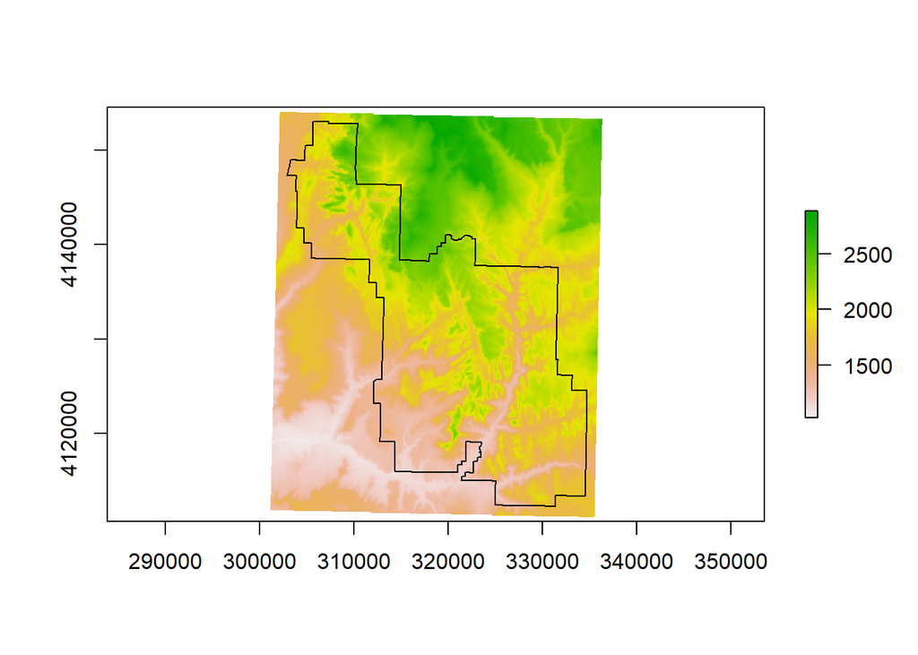

```r
map2 <- plot(srtm_2);plot(zion_2, add = TRUE, col = "transparent")
```